# Environment setup

This project makes use of `Juypter Notebook` as an interacctive shell to write kotlin code. To get it running use the following steps

### 1. Setup a python virtual environment

First install the virtual environment system `virtualenv` . See instructions [here](https://virtualenv.pypa.io/en/stable/installation.html)

In a new directory start a new virtual environment as follows

`virtualenv .`

To start the virtual environment run the following command in the same directory:

`source bin/activate`

### 2. Install `Juypter Notebook`

Next, install notebook using pip

`pip install jupyterlab`

### 3. Installing kotlin kernel

Juypter supports multiple kernels and has python as the default. To run kotlin in the notebooks, we will need to install a kotlin shell.

`pip install kotlin-jupyter-kernel`

### 4. Starting a new notebook

To start a new notebook use the command:

`juypter notebook`

This will open a new browser window pointing to `http://localhost:8888/` or similar. You should now see an option to create a new notebook using kotlin shell.

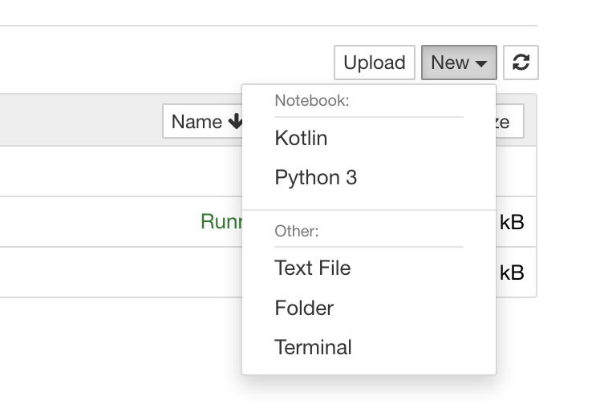

Getting help on default libraries

```kotlin
:help
```

```
Commands:
    :help - display help
    :classpath - show current classpath

Magics
    %use - include supported libraries
        Usage: %use klaxon(5.0.1), lets-plot
    %trackClasspath - log current classpath changes

Supported libraries:
    spark
    koma https://koma.kyonifer.com/index.html
    fuel https://github.com/kittinunf/fuel
    numpy https://github.com/Kotlin/kotlin-numpy
    kotlin-statistics https://github.com/thomasnield/kotlin-statistics
    mysql https://github.com/mysql/mysql-connector-j
    klaxon https://github.com/cbeust/klaxon
    krangl https://github.com/holgerbrandl/krangl
    lets-plot https://github.com/JetBrains/lets-plot-kotlin
    kmath https://github.com/mipt-npm/kmath
    gral https://github.com/eseifert/gral
    kravis https://github.com/holgerbrandl/kravis
    exposed https://github.com/JetBrains/Exposed
```

Adding an external dependency is easy. Here we add `Gson` from https://mvnrepository.com/artifact/com.google.code.gson/gson to the notebook.

```kotlin
@file:Repository("https://repo1.maven.org/maven2/")
@file:DependsOn("com.google.code.gson:gson:2.8.6")
```

```kotlin
//Once the library is added, it can be inported using regular kotlin code.
import com.google.gson.Gson;
val gson = Gson()
```

Next, we will create a new notebook and write some kotlin code